Ficha del establecimiento

# Liceo Polivalente Lo Espejo

RBD **9697**Lo EspejoEscuela o liceoTécnico Profesional

381estudiantes matriculadosCorte Agosto 2026

Mujeres47,8%182 est.

Hombres52,2%199 est.

Chilenos/as69,0%263 est.

Extranjeros/as31,0%118 est.

Actualizada al 05-10-2026

💻Ver ficha completaVersión para computador, con mapas y gráficos interactivos. Pesa varios MB: mejor ábrela con wifi.

🏛️Identificación

## Identificación del establecimiento

Los datos de contacto y las características básicas del establecimiento, tal como están registrados en el Ministerio de Educación. **Si algo está mal o falta, escríbenos** y lo corregimos en la próxima actualización.

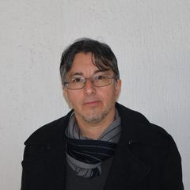

Director o directora

José Cristian Gutierrez Lillo

Seleccionado/a por Alta Direccion Publica

**Nombre**

Liceo Polivalente Lo Espejo

**RBD**

9697

**Dirección**

Ines De Suarez 6970

**Comuna**

Lo Espejo

**Tipo**

Escuela o liceo

**Estado**

✅En funcionamiento

**Director/a**

José Cristian Gutierrez Lillo

**Correo**

liceopolivalenteloespejo@slepsantarosa.cl

**Teléfono**

443144718

**Sitio web**

—

**Matrícula**

GRATUITO

**Sostenedor**

El sostenedor corresponde a una persona jurídica

**Orientación**

Orientación religiosa Laica

### Niveles que imparte

✓ 🧸 Educación Parvularia✓ 🎒 Enseñanza Básica Niños✓ 📘 Media Humanístico-Científica Jóvenes✓ 📖 Media Humanístico-Científica Adultos✓ 🛠️ Media Técnico-Profesional/Artística Jóvenes

### Vulnerabilidad del alumnado

Índice de vulnerabilidad (IVE)

94,9%

Lo calcula JUNAEB y sirve para asignar programas de apoyo.

0%100%

Este establecimientoPromedio de la comuna 88%

Prioritarios en Básica

91,2%

Estudiantes en 1ª, 2ª o 3ª prioridad.

Prioritarios en Media

92,0%

Estudiantes en 1ª, 2ª o 3ª prioridad.

**Un IVE más alto significa más necesidad de apoyo**, no peor calidad. Se usa para decidir a qué establecimientos llegan primero los programas de alimentación, salud y becas.

### Apoyos profesionales al aprendizaje

✓ 📚 Reforzamiento✓ 🧠 Psicólogo/a✓ 🧭 Orientador/a✓ 👩‍🏫 Profesor/a de educación especial✓ 🤝 Asistente social✓ 🗣️ Fonoaudiólogo/a🧩 Psicopedagogo/a🎓 Orientación vocacional➕ Otro

### Infraestructura y atención a la diversidad

✓ 📚 Biblioteca✓ 🔬 Laboratorio✓ 🌐 Computadores con internet✓ 📽️ Sala audiovisual✓ 🏟️ Cancha deportiva✓ ♿ Accesibilidad NEE✓ ➕ Otra: AUDITORIO, SALA TELECOM. Y PSICOMOTRICIDAD.🏛️ Sala multiuso💻 Computadores🖥️ Sala de informática🤾 Gimnasio

✓ 🧠 Discapacidad intelectual✓ 📖 Dificultades de aprendizaje✓ 🗣️ Trastorno específico del lenguaje👁️ Discapacidad visual👂 Discapacidad auditiva🦽 Discapacidad motora🧩 Trastorno del espectro autista💬 Trastornos de la comunicación🎯 Déficit atencional📊 Funcionamiento intelectual limítrofe

Las etiquetas con ✓ son las que el establecimiento declaró en el directorio oficial; las grises no están marcadas.

### Jornada Escolar Completa (JEC)

Cursos con jornada completa

10

Cursos sin jornada completa

6

**Ver curso por curso**

| Grado | Cursos | Jornada |
| --- | --- | --- |
| 1° Básico | 1 | — Sin JEC |
| 1° Medio | 2 | ✅ Con JEC |
| 1° Nivel (Adultos) | 1 | — Sin JEC |
| 2° Básico | 1 | — Sin JEC |
| 2° Medio | 2 | ✅ Con JEC |
| 2° Nivel (Adultos) | 2 | — Sin JEC |
| 3° Básico | 1 | ✅ Con JEC |
| 3° Medio | 2 | ✅ Con JEC |
| 4° Básico | 1 | ✅ Con JEC |
| 4° Medio | 2 | ✅ Con JEC |
| 5° Básico | 1 | ✅ Con JEC |
| 6° Básico | 1 | ✅ Con JEC |
| 7° Básico | 1 | ✅ Con JEC |
| 8° Básico | 1 | ✅ Con JEC |
| Kínder | 1 | — Sin JEC |
| Pre-kínder | 1 | — Sin JEC |

Con **Jornada Escolar Completa** los estudiantes tienen más horas de clases al día y almuerzan en el establecimiento.

### Idiomas

**Inglés en Enseñanza Básica**

Básico

**Inglés en Enseñanza Media**

Intermedio

### Certificación ambiental (SNCAE)

🌿Certificación ambiental nivel Básico

**Inicio de la certificación**

2024

**Término de la certificación**

2026

### Concentración de alumnado prioritario

Concentración 2026

55,8%

▼8,96 pts

Porcentaje de estudiantes prioritarios reconocidos por el Mineduc.

0%100%

Concentración del establecimiento

Concentración 2025

64,8%

Resolución exenta

2026

Observación del Ministerio: **Pierde ACAP en 2026**.

La **concentración de prioritarios** define cuánta Subvención Escolar Preferencial (SEP) recibe el establecimiento. Sobre 60 % da acceso a la asignación por concentración.

### Requisitos para postular

✓ 📄 Certificado de nacimiento✓ 📊 Certificado de notas✓ 📝 Informe de personalidad✓ 🏠 Ficha de protección social✓ ✍️ Firmar el proyecto educativo✓ ⚖️ Firmar el reglamento de convivencia✓ 👥 Entrevista con apoderados🎂 Cumplir la edad mínima🧪 Test de intereses♿ Informe de necesidades educativas📋 Examen de ingreso🎲 Sorteo💍 Certificado de matrimonio⛪ Certificado de bautismo⛪ Certificado de matrimonio religioso💰 Pago de postulación➕ Otro

Desde el Sistema de Admisión Escolar, los establecimientos públicos **no pueden seleccionar** por rendimiento ni por antecedentes socioeconómicos. Estos son los antecedentes administrativos que el establecimiento declara pedir.

**Equipo del SLEP que acompaña al establecimiento**

**Asesor/a territorial**

DIEGO MENDOZA CISTERNAS

**Correo UTP**

utp.liceopolivalenteloespejo@slepsantarosa.cl

**Correo Inspectoría**

inspectoria.liceopolivalenteloespejo@slepsantarosa.cl

🏫Matrícula

## Matrícula y asistencia

Cuántos estudiantes tiene el establecimiento, quiénes son y cuántos días van efectivamente a clases. **La asistencia es el porcentaje de días que los estudiantes asistieron** sobre los días en que estuvieron matriculados.

Matrícula · Agosto 2026

381

▼2,6%

Variación desde el primer mes del año escolar.

1141.024

Este establecimientoPromedio del SLEP 333

Asistencia promedio

83,8%

Días asistidos sobre días matriculados.

74,5%101,5%

Este añoPromedio de años anteriores 84,5%

Cursos

21

Niveles

5

Matrícula regular

322

Estudiantes en la modalidad regular del establecimiento.

Matrícula no regular

59

Modalidades de adultos, reingreso o validación de estudios.

Matrícula mes a mes · 2026

Cuántos estudiantes había registrados al cierre de cada mes.

Asistencia mes a mes · 2026

Porcentaje de días asistidos sobre los días en que el estudiante estuvo matriculado.

Matrícula año a año

Matrícula del último mes de cada año escolar.

### Quiénes estudian acá

Por género

Hombres · 199Mujeres · 182

Por origen

Chilenos/as · 263Extranjeros/as · 118Nacionalizados/as · 0

Nacionalidades presentes

Número de estudiantes por país de nacimiento declarado.

🇨🇱 Chilena293

🇻🇪 Venezolana24

🇭🇹 Haitiana21

🌐 Otra14

🇵🇪 Peruana9

🇨🇴 Colombiana7

Otros13

Pueblos originarios

Estudiantes que declaran pertenecer a un pueblo originario.

🌿 Mapuche9

☀️ Aymara1

### Por nivel de enseñanza

Matrícula por nivel

🧸 Educación Parvularia15

🎒 Enseñanza Básica Niños134

📘 Media Humanístico-Científica Jóvenes108

🛠️ Media Técnico-Profesional/Artística Jóvenes65

📖 Media Humanístico-Científica Adultos59

Asistencia por nivel

La escala va de 0 % a 100 %.

🧸 Educación Parvularia81,6%

🎒 Enseñanza Básica Niños84,4%

📘 Media Humanístico-Científica Jóvenes80,6%

🛠️ Media Técnico-Profesional/Artística Jóvenes82,0%

📖 Media Humanístico-Científica Adultos90,7%

### Asistencia por grupo

Asistencia por género

Promedio ponderado por el número de estudiantes de cada grupo.

Hombres84,7%

Mujeres82,9%

Asistencia por origen

Chilenos/as82,0%

Extranjeros/as87,9%

Asistencia por nacionalidad

Solo los seis grupos con más estudiantes.

🇨🇱 Chilena83,0%

🇻🇪 Venezolana83,7%

🇭🇹 Haitiana94,6%

🌐 Otra83,3%

🇵🇪 Peruana89,9%

🇨🇴 Colombiana85,7%

Asistencia por pueblo originario

🌿 Mapuche79,9%

☀️ Aymara100,0%

### Matrícula técnico-profesional

Estudiantes por especialidad

👶 Atención de párvulos35

📡 Telecomunicaciones30

Asistencia por especialidad

👶 Atención de párvulos0,0%

📡 Telecomunicaciones0,0%

**Ver el detalle curso por curso (21 cursos)**

| Curso | Matrícula | Asistencia % |
| --- | --- | --- |
| Pre-kínder A | 9 | 79,9 |
| Kínder A | 6 | 84,1 |
| 1° Básico A | 11 | 89,6 |
| 2° Básico A | 16 | 80,7 |
| 3° Básico A | 12 | 85,3 |
| 4° Básico A | 15 | 87,9 |
| 5° Básico A | 27 | 80,8 |
| 6° Básico A | 18 | 82,5 |
| 7° Básico A | 15 | 89,5 |
| 8° Básico A | 20 | 84,3 |
| 1° Medio A | 30 | 81,3 |
| 1° Medio B | 30 | 82,4 |
| 2° Medio A | 24 | 83,3 |
| 2° Medio B | 24 | 75 |
| 3° Medio A | 27 | 76,9 |
| 3° Medio B | 18 | 86,5 |
| 4° Medio A | 8 | 83,9 |
| 4° Medio B | 12 | 85,3 |
| 1° Nivel (Adultos) A | 20 | 94,2 |
| 2° Nivel (Adultos) A | 15 | 86,3 |
| 2° Nivel (Adultos) B | 24 | 90,5 |

**Ver la matrícula año a año, con su variación**

| Periodo | Matrícula | Variación | Cambio |
| --- | --- | --- | --- |
| 2026 | 381 | −30,0 | −7,3% |
| 2025 | 411 | +12,0 | +3,0% |
| 2024 | 399 | +17,0 | +4,5% |
| 2023 | 382 | +64,0 | +20,1% |
| 2022 | 318 | −58,0 | −15,4% |
| 2019 | 376 | +45,0 | +13,6% |
| 2018 | 331 | +26,0 | +8,5% |
| 2017 | 305 | +37,0 | +13,8% |
| 2016 | 268 | — | — |

**Ver la asistencia año a año, con su variación**

| Periodo | Asistencia | Variación | Cambio |
| --- | --- | --- | --- |
| 2026 | 83,8% | +4,4 pts | +5,5% |
| 2025 | 79,4% | −7,5 pts | −8,6% |
| 2024 | 86,9% | +0,8 pts | +0,9% |
| 2023 | 86,1% | −13,5 pts | −13,6% |
| 2022 | 99,6% | +21,1 pts | +26,9% |
| 2019 | 78,5% | −4,4 pts | −5,3% |
| 2018 | 82,9% | +6,5 pts | +8,5% |
| 2017 | 76,4% | −10,0 pts | −11,6% |
| 2016 | 86,4% | — | — |

La matrícula se cuenta al cierre de cada mes, así que los cambios durante el año reflejan traslados y retiros. Corte usado: **Agosto 2026**.

🤝Vida escolar

## Vida escolar y comunidad

Qué actividades ofrece el establecimiento fuera de las clases, cómo se organiza con las familias y quiénes representan a la comunidad. **Las etiquetas con ✓ son las que el establecimiento declaró** en el directorio oficial del Ministerio; las grises no están marcadas.

### Talleres y actividades para estudiantes

✓ 🧭 Orientación✓ 🤝 Convivencia✓ 🚫 Prevención drogas✓ ❤️ Educación sexual✓ 🌟 Vida sana✓ ➕ Otra: FORMACIÓN CIUDADANA Y PLAN DE INCLUSIÓN.🌱 Medio ambiente🫂 Acción social✝️ Pastoral

Actividades de formación: orientación, convivencia, prevención y vida sana.

✓ 🎵 Música✓ 💻 Taller TIC🎭 Teatro📚 Literatura✂️ Manualidades🩰 Danza o ballet🎨 Artes plásticas🎓 Preuniversitario➕ Otro

Talleres de arte, cultura y tecnología fuera del horario de clases.

✓ ⚽ Fútbol✓ 🥅 Baby fútbol✓ 🏀 Básquetbol✓ 🏓 Tenis de mesa✓ ➕ Otro: PATINAJE ARTÌSTICO (BÁSICA) Y FUTSAL.🏃 Atletismo🏐 Vóleibol🏊 Natación🤸 Gimnasia🎾 Tenis♟️ Ajedrez

Disciplinas deportivas que ofrece el establecimiento.

### Trabajo con las familias

✓ 👪 Talleres de formación🎉 Actividades de integración📈 Perfeccionamiento➕ Otra

✓ 📒 Libreta de comunicaciones✓ 📄 Reuniones generales✓ 👥 Entrevistas individuales🌐 Web y redes sociales🗣️ Consejo escolar➕ Otro

Por dónde el establecimiento se comunica con apoderados y apoderadas.

### Organizaciones de la comunidad

**Centro de Padres**

Constituido

**Personalidad jurídica**

Vencida

**Última elección de directiva**

**Centro de Estudiantes**

Constituido

**Representante del sostenedor en el Consejo Escolar**

Bruno Cortés González

**Acompañamiento del Consejo Escolar**

Eiden Viera Pardo

Para contactar al centro de padres o al centro de estudiantes, escribe al establecimiento: sus datos están más arriba.

El **Consejo Escolar** es la instancia donde se juntan dirección, docentes, asistentes, apoderados y estudiantes para conversar sobre la marcha del establecimiento.

### Normativa y conectividad

**Uso de uniforme**

Uniforme regular

**Tipo de conexión**

Fibra óptica

**Velocidad de internet**

Sin información

🧭Gestión

## Instrumentos de gestión: PEI y PME

El **PEI** dice quién quiere ser el establecimiento: su misión, su visión y sus sellos. El **PME** dice qué va a hacer este año para lograrlo, con responsables y presupuesto. Son los dos documentos que ordenan el trabajo.

### Proyecto Educativo Institucional (PEI)

**Misión**

Entegrar una educación de calidad, enfocada en el desarrollo intelectual y necesidades del desarrollo armónico de nuestros estudiantes, a través de una propuesta pedagógica orientada al perfil técnico profesional ,humanista ,con conciencia ecológica para insertarse en el contexto social cambiante de manera exitosa y posibilidades de progresar en su futuro .al término de la enseñanza media.

**Visión**

Ser reconocida como la mejor institución técnico profesional dentro de la comuna, a través un compromiso en la formación de personas con valores íntegros y competentes para que logren insertarse con éxito en el campo laboral orientados por una visión ecológica que contribuya la sustentabilidad de los recursos.

### Sellos educativos

✓ S✓ ello 1 : Tecnológico Humanista

### Énfasis declarados, en orden de prioridad

**1º**

Inserción laboral

**2º**

Inclusivo

**3º**

Excelencia académica

### Documentos oficiales

[📘Proyecto Educativo](https://wwwfs.mineduc.cl/Archivos/infoescuelas/documentos/9697/ProyectoEducativo9697.pdf)[⚖️Reglamento de Convivencia](https://wwwfs.mineduc.cl/Archivos/infoescuelas/documentos/9697/ReglamentodeConvivencia9697.pdf)[📊Reglamento de Evaluación](https://wwwfs.mineduc.cl/Archivos/infoescuelas/documentos/9697/ReglamentoDeEvaluacion9697.pdf)

### Plan de Mejoramiento Educativo (PME)

Acciones comprometidas

23

Inversión total del plan

$ 219.775.962

Dimensiones cubiertas

4

Acciones por dimensión

Las cuatro dimensiones del PME: gestión pedagógica, liderazgo, convivencia y recursos.

Gestión de Recursos10

Gestión Pedagógica5

Convivencia Escolar4

Liderazgo4

Quién lidera las acciones

Los cinco responsables con más acciones a cargo.

Director15

Jefe técnico4

Encargado de convivencia3

Sostenedor1

De dónde sale el financiamiento

Monto comprometido por fuente de recursos.

sep$ 219.775.962

**Ver las 23 acciones del plan**

| Acción | Dimensión | Responsable | Monto |
| --- | --- | --- | --- |
| Desarrollo de Proyectos Disciplinarios | Gestión Pedagógica | Jefe técnico | $ 0 |
| Reactivación de la Lectura y la Escritura | Gestión Pedagógica | Jefe técnico | $ 0 |
| Acciones formativas, de perfeccionamiento y capacitación | Gestión Pedagógica | Director | $ 1.000.000 |
| Servicio de Plataforma Educativa | Gestión Pedagógica | Jefe técnico | $ 2.569.911 |
| Extensión horaria para Niveles Sin JEC | Gestión Pedagógica | Jefe técnico | $ 61.162.534 |
| Comunidad de Aprendizaje Profesional | Liderazgo | Director | $ 0 |
| Monitoreo Plan de Mejoramiento Educativo | Liderazgo | Director | $ 0 |
| Contratación de Profesionales para fortalecer la gestión de soporte para los procesos educativos de | Liderazgo | Sostenedor | $ 11.650.006 |
| ADECO: Retroalimentación pedagógica mediante acompañamiento al aula | Liderazgo | Director | $ 0 |
| Mediaciones para el mejoramiento del clima laboral | Convivencia Escolar | Encargado de convivencia | $ 0 |
| Plan de prevención y postvención | Convivencia Escolar | Encargado de convivencia | $ 0 |
| Asistencia y resguardo de las trayectorias educativas (Dupla Psicosocial) | Convivencia Escolar | Encargado de convivencia | $ 15.000.000 |
| Acciones de bienestar para estudiantes | Convivencia Escolar | Director | $ 1.682.412 |
| Servicio de Impresión para el Apoyo Pedagógico | Gestión de Recursos | Director | $ 2.417.989 |
| Adquisición de Material Fungible para Liceos Técnico-Profesionales | Gestión de Recursos | Director | $ 1.435.947 |
| Máquinas y equipos | Gestión de Recursos | Director | $ 1.262.302 |
| Contratación de Docentes y/o Asistentes de la Educación para Apoyo Pedagógico | Gestión de Recursos | Director | $ 108.345.060 |
| Mobiliario y otros | Gestión de Recursos | Director | $ 2.942.769 |
| Compra de Material Escolar para el Apoyo al Aprendizaje | Gestión de Recursos | Director | $ 920.825 |
| Equipos informáticos | Gestión de Recursos | Director | $ 3.021.848 |
| Programas informáticos | Gestión de Recursos | Director | $ 364.359 |
| Recursos para el aprendizaje | Gestión de Recursos | Director | $ 3.000.000 |
| Equipamiento de apoyo pedagógico | Gestión de Recursos | Director | $ 3.000.000 |

**Ver plazos y estado de ejecución de cada acción**

| Acción | Inicio | Término | Nivel de ejecución |
| --- | --- | --- | --- |
| Desarrollo de Proyectos Disciplinarios | 17/4/2025 | 29/12/2025 | Implementación avanzada (75% a 99%) |
| Reactivación de la Lectura y la Escritura | 17/3/2025 | 30/12/2025 | Implementado de manera adecuada (50% a 74%) |
| Acciones formativas, de perfeccionamiento y capacitación | 17/3/2025 | 31/12/2025 | Implementado de manera adecuada (50% a 74%) |
| Servicio de Plataforma Educativa | 17/3/2025 | 31/12/2025 | Implementación avanzada (75% a 99%) |
| Extensión horaria para Niveles Sin JEC | 17/3/2025 | 31/12/2025 | Aún no se encuentra evaluado |
| Comunidad de Aprendizaje Profesional | 21/4/2025 | 29/12/2025 | Implementación avanzada (75% a 99%) |
| Monitoreo Plan de Mejoramiento Educativo | 17/4/2025 | 29/12/2025 | Implementado parcialmente (25 a 49%) |
| Contratación de Profesionales para fortalecer la gestión de soporte para los procesos educativos de | 03/3/2025 | 31/12/2025 | Implementado de manera adecuada (50% a 74%) |
| ADECO: Retroalimentación pedagógica mediante acompañamiento al aula | 15/7/2025 | 30/12/2025 | Implementado de manera adecuada (50% a 74%) |
| Mediaciones para el mejoramiento del clima laboral | 17/4/2025 | 30/12/2025 | Implementado de manera adecuada (50% a 74%) |
| Plan de prevención y postvención | 17/4/2025 | 30/12/2025 | Implementado de manera adecuada (50% a 74%) |
| Asistencia y resguardo de las trayectorias educativas (Dupla Psicosocial) | 01/1/2025 | 31/12/2025 | Implementación avanzada (75% a 99%) |
| Acciones de bienestar para estudiantes | 17/3/2025 | 31/12/2025 | Implementado inicialmente (1% a 24%) |
| Servicio de Impresión para el Apoyo Pedagógico | 17/3/2025 | 31/12/2025 | Implementado parcialmente (25 a 49%) |
| Adquisición de Material Fungible para Liceos Técnico-Profesionales | 17/3/2025 | 31/12/2025 | Implementado parcialmente (25 a 49%) |
| Máquinas y equipos | 17/3/2025 | 31/12/2025 | Implementado inicialmente (1% a 24%) |
| Contratación de Docentes y/o Asistentes de la Educación para Apoyo Pedagógico | 17/3/2025 | 31/12/2025 | Implementado parcialmente (25 a 49%) |
| Mobiliario y otros | 01/1/2025 | 31/12/2025 | Implementado inicialmente (1% a 24%) |
| Compra de Material Escolar para el Apoyo al Aprendizaje | 17/3/2025 | 29/12/2025 | Implementado inicialmente (1% a 24%) |
| Equipos informáticos | 17/3/2025 | 30/12/2025 | Implementado inicialmente (1% a 24%) |
| Programas informáticos | 17/3/2025 | 30/12/2025 | Implementado inicialmente (1% a 24%) |
| Recursos para el aprendizaje | 17/3/2025 | 30/12/2025 | Implementado inicialmente (1% a 24%) |
| Equipamiento de apoyo pedagógico | 17/3/2025 | 31/12/2025 | Implementado inicialmente (1% a 24%) |

**Ver estrategia, programa y medios de verificación**

| Acción | Estrategia | Programa asociado | Medios de verificación |
| --- | --- | --- | --- |
| Desarrollo de Proyectos Disciplinarios | Promoción del trabajo colaborativo para el desarrollo de habilidades en los estudiantes por medio de estrategias didácticas innovadoras inclusivas, el intercambio de experiencias pedagógicas, acompaña… | Plan de Gestión Directiva | -Fotografías -Planificación |
| Reactivación de la Lectura y la Escritura | Promoción del trabajo colaborativo para el desarrollo de habilidades en los estudiantes por medio de estrategias didácticas innovadoras inclusivas, el intercambio de experiencias pedagógicas, acompaña… | CRA | -Programa Plan Lector -Informes de resultados educativos -Planilla monitoreo Plan Lector |
| Acciones formativas, de perfeccionamiento y capacitación | Promoción del trabajo colaborativo para el desarrollo de habilidades en los estudiantes por medio de estrategias didácticas innovadoras inclusivas, el intercambio de experiencias pedagógicas, acompaña… | SEP | -Actas jornada reflexión docente metodologías y estrategias -Programa de capacitación -Listado de asistencia -Plan de Desarrollo Profesional Docente |
| Servicio de Plataforma Educativa | Promoción del trabajo colaborativo para el desarrollo de habilidades en los estudiantes por medio de estrategias didácticas innovadoras inclusivas, el intercambio de experiencias pedagógicas, acompaña… | SEP | -? Reportes -? Informe de notas -? Informe Uso Plataforma |
| Extensión horaria para Niveles Sin JEC | Promoción del trabajo colaborativo para el desarrollo de habilidades en los estudiantes por medio de estrategias didácticas innovadoras inclusivas, el intercambio de experiencias pedagógicas, acompaña… | SEP | -Registro de asistencia -Plan de trabajo |
| Comunidad de Aprendizaje Profesional | Monitoreo trimestral del Plan de Mejoramiento Educativo a través de Grupos Profesionales de Trabajo entre los distintos estamentos del establecimiento | Plan de Gestión Directiva | -Cronograma comunidades de aprendizaje -Actas sesiones comunidades de aprendizaje |
| Monitoreo Plan de Mejoramiento Educativo | Monitoreo trimestral del Plan de Mejoramiento Educativo a través de Grupos Profesionales de Trabajo entre los distintos estamentos del establecimiento | Ninguno | -Planilla monitoreo PME -Acta Monitoreo PME |
| Contratación de Profesionales para fortalecer la gestión de soporte para los procesos educativos de | Monitoreo trimestral del Plan de Mejoramiento Educativo a través de Grupos Profesionales de Trabajo entre los distintos estamentos del establecimiento | SEP | -Informes de avance y ejecución -Convenios de prestación de servicios |
| ADECO: Retroalimentación pedagógica mediante acompañamiento al aula | Monitoreo trimestral del Plan de Mejoramiento Educativo a través de Grupos Profesionales de Trabajo entre los distintos estamentos del establecimiento | Ninguno | -Informes ADECO -Pauta de acompañamiento al aula con retroalimentación |
| Mediaciones para el mejoramiento del clima laboral | Análisis de planes de acción en Grupos Profesionales de Trabajo, para el establecimiento y difusión de lineamientos y programas institucionales que fomenten la amabilidad, el respeto y la cultura de a… | Ninguno | -Programación jornadas de autocuidado o capacitaciones -Resultados aplicación cuestionario clima laboral -Lista de asistencia a capacitaciones |
| Plan de prevención y postvención | Análisis de planes de acción en Grupos Profesionales de Trabajo, para el establecimiento y difusión de lineamientos y programas institucionales que fomenten la amabilidad, el respeto y la cultura de a… | Ninguno | -Cronograma de hitos -Informe de encuestas satisfacción -Informe de Equipo Psicosocial |
| Asistencia y resguardo de las trayectorias educativas (Dupla Psicosocial) | Análisis de planes de acción en Grupos Profesionales de Trabajo, para el establecimiento y difusión de lineamientos y programas institucionales que fomenten la amabilidad, el respeto y la cultura de a… | SEP | -? Informe de impacto -? Plan de trabajo |
| Acciones de bienestar para estudiantes | Análisis de planes de acción en Grupos Profesionales de Trabajo, para el establecimiento y difusión de lineamientos y programas institucionales que fomenten la amabilidad, el respeto y la cultura de a… | SEP | -Facturas -Procesos de compra -Solicitudes de pedido |
| Servicio de Impresión para el Apoyo Pedagógico | Gestión de compras públicas y gestión de competencias profesionales de los docentes y asistentes en función del PEI. | SEP | -? Registro de material impreso -? Contrato suministro -? Informe de impresiones mensuales |
| Adquisición de Material Fungible para Liceos Técnico-Profesionales | Gestión de compras públicas y gestión de competencias profesionales de los docentes y asistentes en función del PEI. | SEP | -? Facturas -? Procesos de compras mediante compra ágil o trato directo |
| Máquinas y equipos | Gestión de compras públicas y gestión de competencias profesionales de los docentes y asistentes en función del PEI. | SEP | -Facturas -Procesos de compras públicas |
| Contratación de Docentes y/o Asistentes de la Educación para Apoyo Pedagógico | Gestión de compras públicas y gestión de competencias profesionales de los docentes y asistentes en función del PEI. | SEP | -? Registro de asistencia -? Plan de trabajo |
| Mobiliario y otros | Gestión de compras públicas y gestión de competencias profesionales de los docentes y asistentes en función del PEI. | PIE | -Licitación y adjudicación -Registro de entrada |
| Compra de Material Escolar para el Apoyo al Aprendizaje | Gestión de compras públicas y gestión de competencias profesionales de los docentes y asistentes en función del PEI. | SEP | -Facturas -Procesos de compras públicas |
| Equipos informáticos | Gestión de compras públicas y gestión de competencias profesionales de los docentes y asistentes en función del PEI. | SEP | -Facturas -Procesos de compras públicas |
| Programas informáticos | Gestión de compras públicas y gestión de competencias profesionales de los docentes y asistentes en función del PEI. | SEP | -Procesos de compras públicas -Facturas -Solicitudes de pedido |
| Recursos para el aprendizaje | Gestión de compras públicas y gestión de competencias profesionales de los docentes y asistentes en función del PEI. | SEP | -Proceso de compras públicas -Facturas |
| Equipamiento de apoyo pedagógico | Gestión de compras públicas y gestión de competencias profesionales de los docentes y asistentes en función del PEI. | SEP | -Procesos de licitación -Facturas |

**Ver la descripción completa y la justificación de cada acción**

| Acción | Qué se hace | Por qué |
| --- | --- | --- |
| Desarrollo de Proyectos Disciplinarios | Trabajo colaborativo entre docentes de ciclos y niveles de enseñanza para la integración y vinculación curricular a través de la preparación, implementación y evaluación de proyectos de aula, ABP, etc… | El nivel de implementación está dentro del curso adecuado en relación a las fechas programadas. |
| Reactivación de la Lectura y la Escritura | Desarrollo del plan lector con foco en la adquisición de la lectura oral, comprensiva y en la escritura, a través de la estructura semanal de la asignatura, con apoyo de asistentes de aula, coordinado… | El nivel de implementación está dentro del curso adecuado en relación a las fechas programadas. |
| Acciones formativas, de perfeccionamiento y capacitación | Acciones formativas, de perfeccionamiento y capacitación para docentes y asistentes con temáticas relacionadas en Desarrollo profesional docente, Metodología para la enseñanza y aprendizaje de la lect… | El nivel de implementación está dentro del curso adecuado en relación a las fechas programadas. |
| Servicio de Plataforma Educativa | La plataforma educativa es una herramienta digital que facilita la planificación, implementación y seguimiento con un enfoque pedagógico. Su propósito es fortalecer la gestión curricular y didáctica, … | El nivel de implementación está dentro del curso adecuado en relación a las fechas programadas. |
| Extensión horaria para Niveles Sin JEC | La extensión horaria de profesionales y técnicos permite a nuestros estudiantes acceder a diversas herramientas de aprendizaje y participar en experiencias educativas alternativas, lúdicas y enriquece… | Aún no se encuentra evaluado |
| Comunidad de Aprendizaje Profesional | Generar comunidades de aprendizaje profesional por niveles, quienes se reunirán bimensualmente con el objetivo de enriquecer y reflexionar a partir de sus prácticas pedagógicas, compartir experiencias… | El nivel de implementación está dentro del curso adecuado en relación a las fechas programadas. |
| Monitoreo Plan de Mejoramiento Educativo | Monitoreo semestral del avance del Plan de Mejoramiento Educativo, el cual se realizará participativamente por miembros del equipo de gestión 2 representantes de docentes y representantes de asistente… | El nivel de implementación está dentro del curso adecuado en relación a las fechas programadas. |
| Contratación de Profesionales para fortalecer la gestión de soporte para los procesos educativos de | Contratación de profesionales especializados en distintas áreas para fortalecer la gestión de los procesos educativos en los establecimientos educacionales, optimizando la planificación, seguimiento y… | El nivel de implementación está dentro del curso adecuado en relación a las fechas programadas. |
| ADECO: Retroalimentación pedagógica mediante acompañamiento al aula | Mediante visitas al aula el equipo directivo autoevalúa su gestión, analiza el mejoramiento de sus prácticas directivas, el avance en el fortalecimiento profesional de sus docentes y la contribución e… | El nivel de implementación está dentro del curso adecuado en relación a las fechas programadas. |
| Mediaciones para el mejoramiento del clima laboral | Intervenciones de bienestar para funcionarios, mediante a) lista de redes de asistencia psicosocial disponibles a la comunidad, b) Trabajo de cuidado colectivo con redes externas, como puede ser HPV o… | El nivel de implementación está dentro del curso adecuado en relación a las fechas programadas. |
| Plan de prevención y postvención | Se implementa un plan preventivo que considere ferias promocionales semestrales de prevención de: Bullying, Ciberbullying, delitos sexuales, auto cuidado, resolución de conflictos, alcohol y drogas, f… | El nivel de implementación está dentro del curso adecuado en relación a las fechas programadas. |
| Asistencia y resguardo de las trayectorias educativas (Dupla Psicosocial) | Contratación de especialistas del área psicosocial, como trabajadores sociales, psicólogos y coordinadores, para fortalecer el acompañamiento integral de los y las estudiantes y garantizar su continui… | El nivel de implementación está dentro del curso adecuado en relación a las fechas programadas. |
| Acciones de bienestar para estudiantes | Adquisición de toldo Plegable 3x3 mt azul tipo araña, escarapelas premiación ( 1°-2°-3°), Medallas y galvanos, piocha Individualizada, jockey personalizados Liceo Polivalente, vestuario para carreras … | El nivel de implementación está dentro del curso adecuado en relación a las fechas programadas. |
| Servicio de Impresión para el Apoyo Pedagógico | La contratación de servicios de impresión garantiza la disponibilidad de material didáctico de calidad para fortalecer los procesos de enseñanza y aprendizaje. Permite a docentes y estudiantes acceder… | El nivel de implementación está dentro del curso adecuado en relación a las fechas programadas. |
| Adquisición de Material Fungible para Liceos Técnico-Profesionales | La compra de material fungible es fundamental para el desarrollo de aprendizajes prácticos en los liceos técnico-profesionales, permitiendo a los y las estudiantes aplicar conocimientos en entornos si… | El nivel de implementación está dentro del curso adecuado en relación a las fechas programadas. |
| Máquinas y equipos | Adquisición de cámaras de imágenes y video, equipos de sonido y amplificación, telón para data show, aire acondicionado | El nivel de implementación está dentro del curso adecuado en relación a las fechas programadas. |
| Contratación de Docentes y/o Asistentes de la Educación para Apoyo Pedagógico | La contratación de docentes y asistentes de la educación tiene como objetivo fortalecer y apoyar los procesos pedagógicos, brindando un acompañamiento especializado a los estudiantes. Estos profesiona… | El nivel de implementación está dentro del curso adecuado en relación a las fechas programadas. |
| Mobiliario y otros | Adquisición de muebles para uso pedagógico con el objetivo de implementar biblioteca, sala de contención emocional, laboratorios, mesas sala de enlaces, estantes, escritorios, sillas para sala de enla… | El nivel de implementación está dentro del curso adecuado en relación a las fechas programadas. |
| Compra de Material Escolar para el Apoyo al Aprendizaje | La adquisición de material escolar asegura que todos los estudiantes cuenten con los recursos necesarios para su desarrollo académico, facilitando su participación en las actividades pedagógicas y fav… | El nivel de implementación está dentro del curso adecuado en relación a las fechas programadas. |
| Equipos informáticos | Adquisición de equipos de sonido y amplificación, equipo para videoconferencia, proyector, notebook, cintas magnéticas de respaldo y limpieza, discos duros, impresoras, router | El nivel de implementación está dentro del curso adecuado en relación a las fechas programadas. |
| Programas informáticos | Adquisición de software, procesadores de textos, planillas electrónicas, bases de datos, licencias | El nivel de implementación está dentro del curso adecuado en relación a las fechas programadas. |
| Recursos para el aprendizaje | Gastos en recursos de aprendizaje que favorezcan la formación integral de todos los alumnos y alumnas del establecimiento, implementos de laboratorio, deportivos, instrumentos musicales y artísticos, … | El nivel de implementación está dentro del curso adecuado en relación a las fechas programadas. |
| Equipamiento de apoyo pedagógico | Adquisición de equipamiento de carácter formativo, didáctico, académico y pedagógico necesarios para las actividades educativas propias de los establecimientos, con el fin de mejorar el proceso de ens… | El nivel de implementación está dentro del curso adecuado en relación a las fechas programadas. |

🏆SNED

## SNED · Sistema Nacional de Evaluación del Desempeño

El SNED evalúa cada dos años el desempeño de los establecimientos municipales y particulares subvencionados. Mira **seis factores**: efectividad, superación, igualdad de oportunidades, iniciativa, integración y mejoramiento.

⚪No seleccionado

Índice SNED del establecimiento

Va de 0 a 100 y resume los seis factores que evalúa el sistema.

Los seis factores, uno por uno

Cada factor va de 0 a 100. Los de arriba pesan más en el índice final.

Efectividad46,8%

Superación41,6%

Igualdad de oportunidades92,7%

Iniciativa77,6%

Integración47,8%

Mejoramiento99,7%

**¿Cuánto pesa cada factor?**

| Factor | Puntaje | Peso en el índice (%) |
| --- | --- | --- |
| Efectividad | 46,8 | 37 |
| Superación | 41,6 | 28 |
| Igualdad de oportunidades | 92,7 | 22 |
| Iniciativa | 77,6 | 6 |
| Integración | 47,8 | 5 |
| Mejoramiento | 99,7 | 2 |

El SNED premia con un bono a los equipos de los establecimientos con mejor desempeño dentro de un grupo de escuelas parecidas. **No es una nota**: compara con establecimientos de condiciones similares, no con todo Chile.

💼Ocupación

## Ocupación de cupos

Cuántos de los cupos que el establecimiento ofreció están efectivamente ocupados. **Se calcula dividiendo la matrícula actual por los cupos declarados** en el Sistema de Admisión Escolar (SAE).

🚨Con muchos cupos disponibles

Ocupación de los cupos

La marca gris señala el 100 %: por sobre esa línea hay más estudiantes que cupos declarados.

Cupos declarados (SAE)

Matrícula al corte

381

Agosto 2026

Cupos libres

197

Cupos que quedan sin usar.

Vacantes en el curso de ingreso

14

**Ver los cupos declarados por grado**

| Grado | Cursos | Cupos |
| --- | --- | --- |
| 1° Básico | 1 | 30 |
| 1° Medio | 2 | 66 |
| 2° Básico | 1 | 36 |
| 2° Medio | 2 | 72 |
| 3° Básico | 1 | 30 |
| 3° Medio | 2 | 66 |
| 4° Básico | 1 | 36 |
| 4° Medio | 2 | 60 |
| 5° Básico | 1 | 30 |
| 6° Básico | 1 | 36 |
| 7° Básico | 1 | 36 |
| 8° Básico | 1 | 36 |
| Kínder | 1 | 25 |
| Pre-kínder | 1 | 25 |

La ocupación compara la **matrícula efectiva** con los **cupos que el establecimiento declaró** en el Sistema de Admisión Escolar. Una ocupación baja no siempre es mala: puede ser espacio para crecer.

♿PIE

## Programa de Integración Escolar (PIE)

Cuántos estudiantes reciben apoyos del PIE y qué tipo de apoyo necesitan. Las **necesidades permanentes** acompañan toda la trayectoria escolar; las **transitorias** requieren apoyo por un tiempo determinado.

Estudiantes en PIE · 2026

63

Se cuenta cada estudiante una sola vez.

0,0%40,0%

Porcentaje de la matrícula

NEE permanentes

21

Acompañan toda la trayectoria escolar.

NEE transitorias

42

Requieren apoyo por un tiempo acotado.

Sobre la matrícula

16,5%

Tipo de necesidad educativa

NEE permanentes · 21NEE transitorias · 42

Por género

Hombres · 37Mujeres · 26

Diagnósticos más frecuentes

Los ocho diagnósticos con más estudiantes.

Trastorno del Lenguaje16

Funcionamiento Intelectual Limítrofe15

Discapacidad Intelectual13

Dificultades Específicas del Aprendizaje10

Trastorno del Espectro Autista8

Trastorno de Déficit Atencional1

En qué cursos están

1° Medio10

3° Medio8

5° Básico7

3° Básico6

4° Básico6

2° Básico5

2° Medio5

4° Medio4

8° Básico4

6° Básico3

1° Básico2

Kínder2

7° Básico1

Por nivel de enseñanza

Enseñanza Básica Niños34

Media Humanístico-Científica Jóvenes15

Media Técnico-Profesional/Artística Jóvenes12

Educación Parvularia2

**Ver el cruce entre género y tipo de necesidad**

| Genero | PERMANENTE | TRANSITORIO |
| --- | --- | --- |
| Femenino | 7 | 19 |
| Masculino | 14 | 23 |

**Ver el cruce entre género y los diagnósticos más frecuentes**

| Genero | Dificultades Específicas del Aprendizaje | Discapacidad Intelectual | Funcionamiento Intelectual Limítrofe | Trastorno del Lenguaje | Trastorno del Espectro Autista |
| --- | --- | --- | --- | --- | --- |
| Femenino | 6 | 7 | 5 | 8 | 0 |
| Masculino | 4 | 6 | 10 | 8 | 8 |

**Ver todos los diagnósticos registrados**

| Diagnóstico | Tipo de NEE | Estudiantes |
| --- | --- | --- |
| Trastorno del Lenguaje | TRANSITORIO | 16 |
| Funcionamiento Intelectual Limítrofe | TRANSITORIO | 15 |
| Discapacidad Intelectual | PERMANENTE | 13 |
| Dificultades Específicas del Aprendizaje | TRANSITORIO | 10 |
| Trastorno del Espectro Autista | PERMANENTE | 8 |
| Trastorno de Déficit Atencional | TRANSITORIO | 1 |

### Postulaciones al programa, por período

Estudiantes por año y período

El período **Regular** es la postulación anual; **Extraordinario** y **Excepcionalidad** son cupos que se abren después.

2026 · Excepcionalidad6

2026 · Extraordinario2

2026 · Regular86

2025 · Excepcionalidad5

2025 · Regular78

2024 · Regular + Excepcionalidad104

**Ver el detalle por año, período y tipo de necesidad**

| Año | Período | Tipo de NEE | Estudiantes |
| --- | --- | --- | --- |
| 2.026 | Excepcionalidad | PERMANENTE | 6 |
| 2.026 | Extraordinario | TRANSITORIO | 2 |
| 2.026 | Regular | PERMANENTE | 22 |
| 2.026 | Regular | TRANSITORIO | 64 |
| 2.025 | Excepcionalidad | PERMANENTE | 5 |
| 2.025 | Regular | PERMANENTE | 24 |
| 2.025 | Regular | TRANSITORIO | 54 |
| 2.024 | Regular + Excepcionalidad | PERMANENTE | 33 |
| 2.024 | Regular + Excepcionalidad | TRANSITORIO | 71 |

Evolución del programa

Fuente: base territorial del Área de Inclusión Educativa del SLEP.

El PIE entrega apoyos dentro del aula a estudiantes con necesidades educativas especiales. **Estar en PIE no es un diagnóstico permanente**: muchas necesidades son transitorias y se superan con apoyo.

🔄Retiros

## Retiros y movilidad estudiantil

Cuántos estudiantes se retiraron del establecimiento, cuándo y hacia dónde. **Lo importante es saber si volvieron a matricularse en otra parte**: quienes no lo hicieron son los casos que hay que buscar.

Retiros en 2026

69

Equivale al 18,1% de la matrícula actual.

Ya están en otro establecimiento

28

Se confirmó matrícula posterior.

Sin matrícula vigente

14

Requieren seguimiento: pueden estar fuera del sistema.

Pendiente en SIGE

27

Todavía sin información de destino.

En qué meses se producen

Tipo de movimiento

Sin matrícula28

Cambio a otro EE fuera del SLEP24

Cambio a otro EE pertenenciente al SLEP10

Colisión dentro del mismo establecimiento7

A qué establecimientos se van

Los seis destinos más frecuentes.

Sin destino informado28

Liceo Polivalente Lo Espejo7

Liceo Politecnico Part.sagrado Corazon5

Liceo Técnico Clotario Blest Riffo3

Centro Duc.cardenal José María Caro2

Colegio Parque Las Americas2

Desde qué cursos

3° Medio15

2° Nivel (Adultos)12

2° Medio8

1° Medio7

1° Nivel (Adultos)7

5° Básico4

8° Básico4

4° Medio3

2° Básico2

3° Básico2

Pre-kínder2

6° Básico1

7° Básico1

Kínder1

Qué tipo de establecimiento eligieron

Dependencia del establecimiento de destino.

Sin Matrícula28

Mismo Slep17

Particular Subvencionado17

Administración Delegada4

Otro Slep3

A qué comunas se fueron

Sin información28

Lo Espejo22

Pedro Aguirre Cerda9

La Cisterna2

Puente Alto2

San Miguel2

La Granja1

San Bernardo1

**Ver todos los destinos, uno por uno**

| Establecimiento | Comuna | Dependencia | Estudiantes |
| --- | --- | --- | --- |
| Sin destino informado | — | Sin Matrícula | 28 |
| Liceo Polivalente Lo Espejo | Lo Espejo | Mismo Slep | 7 |
| Liceo Politecnico Part.sagrado Corazon | Lo Espejo | Particular Subvencionado | 5 |
| Liceo Técnico Clotario Blest Riffo | Pedro Aguirre Cerda | Administración Delegada | 3 |
| Centro Duc.cardenal José María Caro | Lo Espejo | Mismo Slep | 2 |
| Colegio Parque Las Americas | Pedro Aguirre Cerda | Mismo Slep | 2 |
| Colegio San Lucas De Lo Espejo | Lo Espejo | Particular Subvencionado | 2 |
| Colegio Sol De Chile | Lo Espejo | Particular Subvencionado | 2 |
| Liceo Politecnico San Luis | San Miguel | Particular Subvencionado | 2 |
| Liceo Teniente Francisco Mery Aguirre | Lo Espejo | Mismo Slep | 2 |
| C.e.i.a.pedro Aguirre Cerda | Pedro Aguirre Cerda | Mismo Slep | 1 |
| Colegio Alma Mater | La Granja | Particular Subvencionado | 1 |
| Colegio Corazones De Jesus | Lo Espejo | Particular Subvencionado | 1 |
| Colegio Educad Lo Espejo | Lo Espejo | Particular Subvencionado | 1 |
| Colegio Poliv. San Bernardo Abad | San Bernardo | Particular Subvencionado | 1 |
| Complejo Educacional San Alfonso | Puente Alto | Particular Subvencionado | 1 |
| Esc. Bas. Patr. Willins Hoover Kurt | La Cisterna | Particular Subvencionado | 1 |
| Escuela Bas. Oscar Encalada Yovanovich | La Cisterna | Mismo Slep | 1 |
| Escuela La Victoria | Pedro Aguirre Cerda | Mismo Slep | 1 |
| Escuela Las Palmas | Puente Alto | Otro Slep | 1 |
| Instituto Comercial Padre Alberto Hurtado De Pedro Aguirre Cerda | Pedro Aguirre Cerda | Administración Delegada | 1 |
| Liceo Bicentenario Politecnico Manuel Montt | Victoria | Otro Slep | 1 |
| Liceo Ignacio Carrera Pinto | San Vicente | Otro Slep | 1 |
| Liceo Polivalente Eugenio Pereira Salas | Pedro Aguirre Cerda | Mismo Slep | 1 |

Un retiro no siempre es una pérdida: muchas veces la familia se cambia de comuna. Lo que sí requiere seguimiento son los estudiantes **sin matrícula vigente** en ningún otro establecimiento.

📚Resultados

## Resultados educativos

Cómo les fue a los estudiantes en sus notas y cuántos pasaron de curso. El **promedio general** va de 1,0 a 7,0 y la **tasa de aprobación** es el porcentaje de estudiantes que fue promovido al curso siguiente.

Promedio general · 2025

5,5de 7,0

Promedio de todas las notas finales, ponderado por el tamaño de cada curso.

5,46,3

Este establecimientoPromedio del SLEP 5,9

Tasa de aprobación

94,4%

Promovidos sobre el total de estudiantes con situación final.

50%100%

Este establecimientoPromedio del SLEP 97%

Estudiantes promovidos

368

Estudiantes reprobados

22

Cómo terminó el año 2025

Situación final de cada estudiante al cierre del año escolar.

Promovidos · 368Reprobados · 22Retirados · 57Trasladados · 60

Promedio general año a año

Escala de notas de 1,0 a 7,0.

Tasa de aprobación año a año

Porcentaje de estudiantes promovidos.

**Ver el detalle por curso (14 grados)**

| Grado | Estudiantes | Promedio | Aprobación % |
| --- | --- | --- | --- |
| 1° Básico | 23 | 5,9 | 100 |
| 1° Medio | 85 | 5,1 | 86,2 |
| 1° Nivel (Adultos) | 51 | 5,3 | 89,5 |
| 2° Básico | 17 | 6 | 93,3 |
| 2° Medio | 68 | 5,4 | 98,3 |
| 2° Nivel (Adultos) | 53 | 5,2 | 90,3 |
| 3° Básico | 19 | 6,2 | 100 |
| 3° Medio | 32 | 5,3 | 80 |
| 4° Básico | 29 | 6,2 | 100 |
| 4° Medio | 36 | 5,8 | 100 |
| 5° Básico | 22 | 5,6 | 94,1 |
| 6° Básico | 14 | 6 | 100 |
| 7° Básico | 27 | 5,9 | 100 |
| 8° Básico | 31 | 5,8 | 100 |

### Aprobación por grupo

Tasa de aprobación por género

Masculino92,8%

Femenino96,4%

Tasa de aprobación por origen

Chileno94,5%

Extranjero94,1%

**Ver el promedio de notas por grupo**

| Género | Estudiantes | Promedio | Aprobación % |
| --- | --- | --- | --- |
| Masculino | 278 | 5,4 | 92,8 |
| Femenino | 229 | 5,7 | 96,4 |

| Origen | Estudiantes | Promedio | Aprobación % |
| --- | --- | --- | --- |
| Chileno | 370 | 5,5 | 94,5 |
| Extranjero | 137 | 5,7 | 94,1 |

### Cómo terminó cada año

Año 2025

Promovidos · 368Reprobados · 22Retirados · 57Trasladados · 60

Año 2024

Año 2023

Año 2022

**Ver la tabla de situación final año a año**

| Año | Promovidos | Reprobados | Retirados | Trasladados |
| --- | --- | --- | --- | --- |
| 2.025 | 368 | 22 | 57 | 60 |
| 2.024 | 351 | 15 | 40 | 43 |
| 2.023 | 351 | 5 | 38 | 26 |
| 2.022 | 280 | 15 | 51 | 29 |

**Ver el promedio y la aprobación año a año**

| Periodo | Promedio | Variación | Cambio |
| --- | --- | --- | --- |
| 2025 | 5,5 | −0,1 | −2,3% |
| 2024 | 5,7 | −0,0 | −0,7% |
| 2023 | 5,7 | +0,1 | +1,6% |
| 2022 | 5,6 | — | — |

| Periodo | Aprobación | Variación | Cambio |
| --- | --- | --- | --- |
| 2025 | 94,4% | −1,5 pts | −1,6% |
| 2024 | 95,9% | −2,7 pts | −2,7% |
| 2023 | 98,6% | +3,7 pts | +3,9% |
| 2022 | 94,9% | — | — |

La tasa de aprobación deja fuera a quienes se retiraron o se trasladaron durante el año: **solo considera a quienes terminaron el año en el establecimiento**.

📐SIMCE

## SIMCE

El SIMCE es la prueba que aplica la Agencia de Calidad para saber cuánto aprendieron los estudiantes en Lectura y Matemática. Además del puntaje, muestra **cuántos estudiantes quedaron en cada nivel de aprendizaje**: Insuficiente, Elemental o Adecuado.

### Categoría de desempeño

•Básica 2019: SIN CATEGORIA: BAJA MATRICULA🚨Media 2019: INSUFICIENTE

La categoría de desempeño la asigna la Agencia de Calidad y considera resultados **y** el contexto social del establecimiento. Va de Alto a Insuficiente.

### Resultados por curso

Última medición disponible: **2025**.

Lectura

222pts

▼40 pts

Variación respecto de la medición anterior.

218277

Última mediciónPromedio de años anteriores 251

Matemática

218pts

▼31 pts

Variación respecto de la medición anterior.

204252

Última mediciónPromedio de años anteriores 234

### ¿El cambio es real?

•Lectura ▼Baja de forma significativa•Matemática ▼Baja de forma significativa

La Agencia de Calidad indica si la diferencia con la medición anterior es **estadísticamente significativa**. Si no lo es, el cambio puede deberse al azar.

Niveles de aprendizaje · Lectura

Porcentaje de estudiantes en cada nivel de logro.

Insuficiente · 60,9%Elemental · 34,8%Adecuado · 4,3%

Niveles de aprendizaje · Matemática

Porcentaje de estudiantes en cada nivel de logro.

Insuficiente · 83,3%Elemental · 16,7%Adecuado · 0,0%

Evolución de los puntajes

Puntaje promedio del establecimiento en cada medición.

LecturaMatemática

**Comparar con establecimientos de condiciones parecidas**

| Prueba | Este establecimiento | Grupo de comparación | Diferencia |
| --- | --- | --- | --- |
| Lectura | 222 | 259 | −37 pts |
| Matemática | 218 | 243 | −25 pts |

El grupo de comparación reúne establecimientos con estudiantes de condiciones socioeconómicas similares.

**Ver todos los puntajes históricos**

| Prueba | Año | Puntaje | Estudiantes |
| --- | --- | --- | --- |
| Lectura | 2018 | 233 | 15 |
| Lectura | 2022 | 236 | 11 |
| Lectura | 2023 | 273 | 11 |
| Lectura | 2024 | 262 | 15 |
| Lectura | 2025 | 222 | — |
| Matemática | 2018 | 207 | 14 |
| Matemática | 2022 | 234 | 11 |
| Matemática | 2023 | 246 | 11 |
| Matemática | 2024 | 249 | 16 |
| Matemática | 2025 | 218 | — |

Los puntajes SIMCE van aproximadamente de 100 a 400. Una diferencia de menos de 10 puntos entre dos años **no suele ser significativa**: conviene mirar la tendencia de varios años, no el salto de uno.

🌱IDPS

## Indicadores de Desarrollo Personal y Social

Los IDPS miden cosas que no salen en una prueba: si los estudiantes se sienten capaces de aprender, si el ambiente es sano, si participan y si tienen hábitos saludables. **Van de 0 a 100** y se comparan con establecimientos de condiciones parecidas.

Última medición disponible: **2025**.

Autoestima académica y motivación escolar

71de 100

▼1 pts

Variación respecto de la medición anterior.

0100

Este establecimientoEstablecimientos parecidos 76

Clima de convivencia escolar

62de 100

▼5 pts

Variación respecto de la medición anterior.

0100

Este establecimientoEstablecimientos parecidos 76

Hábitos de vida saludable

66de 100

▲13 pts

Variación respecto de la medición anterior.

0100

Este establecimientoEstablecimientos parecidos 71

Participación y formación ciudadana

72de 100

▲4 pts

Variación respecto de la medición anterior.

0100

Este establecimientoEstablecimientos parecidos 80

### ¿El cambio es real?

•Autoestima académica y motivación escolar ■Sin cambio significativo•Clima de convivencia escolar ▼Baja de forma significativa•Hábitos de vida saludable ▲Sube de forma significativa•Participación y formación ciudadana ■Sin cambio significativo

Evolución de los cuatro indicadores

Autoestima académica y motivación escolarClima de convivencia escolarParticipación y formación ciudadanaHábitos de vida saludable

**Ver todos los puntajes históricos y su grupo de comparación**

| Indicador | Año | Puntaje | Grupo de comparación |
| --- | --- | --- | --- |
| Autoestima académica y motivación escolar | 2025 | 71 | 76 |
| Clima de convivencia escolar | 2025 | 62 | 76 |
| Hábitos de vida saludable | 2025 | 66 | 71 |
| Participación y formación ciudadana | 2025 | 72 | 80 |
| Autoestima académica y motivación escolar | 2024 | 72 | 75 |
| Clima de convivencia escolar | 2024 | 67 | 75 |
| Hábitos de vida saludable | 2024 | 53 | 71 |
| Participación y formación ciudadana | 2024 | 68 | 79 |
| Autoestima académica y motivación escolar | 2023 | 77 | — |
| Clima de convivencia escolar | 2023 | 74 | — |
| Hábitos de vida saludable | 2023 | 74 | — |
| Participación y formación ciudadana | 2023 | 78 | — |
| Autoestima académica y motivación escolar | 2022 | 65 | — |
| Clima de convivencia escolar | 2022 | 73 | — |
| Hábitos de vida saludable | 2022 | 66 | — |
| Participación y formación ciudadana | 2022 | 69 | — |
| Autoestima académica y motivación escolar | 2018 | 71 | — |
| Clima de convivencia escolar | 2018 | 66 | — |
| Hábitos de vida saludable | 2018 | 61 | — |
| Participación y formación ciudadana | 2018 | 74 | — |

Los IDPS se construyen con encuestas a estudiantes, docentes y apoderados. Van de 0 a 100 y **pesan un 33 % en la categoría de desempeño** que la Agencia de Calidad asigna al establecimiento.

📄DIA

## DIA de cierre

El Diagnóstico Integral de Aprendizajes (DIA) se aplica al cierre del año para ver qué aprendieron los estudiantes. **No pone notas**: clasifica a cada estudiante en un nivel de logro para orientar el trabajo del año siguiente.

Estudiantes evaluados

180

Aplicación 2025

En nivel 1 (inicial)

86

En nivel 2 (intermedio)

45

En nivel 3 (adecuado)

49

Cursos evaluados

9

Cómo se reparten los niveles de logro

Cuántos estudiantes quedaron en cada nivel.

Nivel 1 · inicial · 86Nivel 2 · intermedio · 45Nivel 3 · adecuado · 49

Logro promedio por eje de la prueba

Porcentaje de respuestas correctas en cada eje evaluado.

Números y operaciones50,9%

Patrones y álgebra52,2%

Geometría52,3%

Datos y probabilidades51,9%

**Ver el detalle por curso (9 cursos)**

| Curso | Estudiantes | Nivel I | Nivel II | Nivel III |
| --- | --- | --- | --- | --- |
| 1° Básico | 17 | 0 | 4 | 13 |
| 2° Básico | 13 | 1 | 8 | 4 |
| 3° Básico | 9 | 0 | 1 | 8 |
| 4° Básico | 22 | 1 | 3 | 18 |
| 7° Básico | 18 | 6 | 7 | 5 |
| 8° Básico | 20 | 11 | 9 | 0 |
| 1° Medio | 25 | 20 | 5 | 0 |
| 2° Medio | 28 | 28 | 0 | 0 |
| 2° Medio | 28 | 19 | 8 | 1 |

El DIA es una evaluación **de diagnóstico, no una calificación**: sirve para que el equipo docente sepa dónde reforzar. Los niveles van de 1 (requiere más apoyo) a 3 (logro adecuado).

📈PAES

## PAES

La PAES es la prueba que se rinde para postular a la educación superior. Aquí verás **cuántos estudiantes la rindieron** y qué puntaje promedio obtuvieron, comparado con el promedio del SLEP y el nacional.

Proceso de admisión **2026** · 44 estudiantes de la promoción del año.

Rindieron la prueba

24

Es el 54,5% de los inscritos.

0%100%

Porcentaje que rindió

Puntaje NEM

591pts

Puntaje Ranking

627pts

### Puntaje promedio por prueba

Competencia Lectora

524pts

Promedio nacional: 609 pts.

150800

Este establecimientoPromedio del SLEP 553

Matemática 1

522pts

Promedio nacional: 631 pts.

150800

Este establecimientoPromedio del SLEP 565

Matemática 2

387pts

Promedio nacional: 424 pts.

150800

Este establecimientoPromedio del SLEP 396

Historia y Cs. Sociales

442pts

Promedio nacional: 509 pts.

150800

Este establecimientoPromedio del SLEP 463

Ciencias

390pts

Promedio nacional: 473 pts.

150800

Este establecimientoPromedio del SLEP 422

Evolución de los puntajes

Promedio del establecimiento en cada proceso de admisión.

Competencia LectoraMatemática 1

### Por rama educacional

| Rama | Estudiantes | Competencia Lectora | Matemática 1 | Matemática 2 | Historia y Cs. Sociales | Ciencias |
| --- | --- | --- | --- | --- | --- | --- |
| HC nocturno | 19 | 516 | 511 | 372 | 446 | 371 |
| TP industrial | 18 | 544 | 527 | 368 | 446 | 393 |
| TP servicios y técnica | 13 | 497 | 536 | 417 | 453 | 389 |

La **rama** distingue la formación humanístico-científica de la técnico-profesional, y el horario diurno del vespertino.

**Ver quiénes rindieron: promoción del año y años anteriores**

| Situación de egreso | Inscritos | Rindieron |
| --- | --- | --- |
| Promoción año nacional regular | 44 | 24 |
| Promoción anterior nacional regular | 6 | 2 |

Cada proceso de admisión incluye a la promoción del año y también a egresados de años anteriores que vuelven a rendir.

**Comparar con otros tipos de establecimiento**

| Categoria | Competencia Lectora | Matemática 1 | Matemática 2 | Historia y Cs. Sociales | Ciencias |
| --- | --- | --- | --- | --- | --- |
| Promedio Nacional | 609 | 631 | 424 | 509 | 473 |
| SLEP Santa Rosa | 553 | 565 | 396 | 463 | 422 |
| Municipal | 575 | 589 | 402 | 475 | 438 |
| Particular pagado | 716 | 777 | 512 | 637 | 612 |
| Particular subvencionado | 607 | 627 | 415 | 505 | 466 |
| Servicio Local de Educación | 566 | 575 | 397 | 466 | 429 |

Fuente: resultados oficiales del proceso de admisión.

Los puntajes PAES van de 100 a 1.000. Se promedia **solo a quienes efectivamente rindieron** cada prueba, así que Matemática 2 y Ciencias suelen tener menos estudiantes detrás.

🎓Ed. superior

## Tránsito a la educación superior

Qué pasó con los estudiantes después de egresar: cuántos entraron a una universidad, instituto profesional o centro de formación técnica, y qué estudian. **Se mira el año inmediatamente siguiente al egreso**.

Egresados 2024

60

Estudiantes que terminaron 4° medio ese año.

Entraron a educación superior

17

Se matricularon en 2025.

0%100%

Cobertura de acceso inmediato

Cobertura de acceso inmediato

28,3%

No registran matrícula

43

Pueden haber entrado más tarde o seguido otro camino.

En qué tipo de institución entraron

Sin información · 43Institutos Profesionales · 8Universidades · 8Centros de Formación Técnica · 1

Por género

Sin información · 43Masculino · 10Femenino · 7

**Ver dónde y qué estudian**

Instituciones más elegidas

UNIVERSIDAD DE SANTIAGO DE CHILE5

IP DUOC UC4

CFT INACAP1

IP DE CHILE1

IP INACAP1

IP SAN SEBASTIAN1

Carreras más elegidas

INGENIERIA EN REDES Y TELECOMUNICACIONES2

ANALISIS Y GESTION DE PROCESOS PRODUCTIVOS1

DERECHO1

DISEÑO1

INGENIERIA COMERCIAL1

INGENIERIA DE EJECUCION EN COMPUTACION E INFORMATICA1

Áreas del conocimiento

Tecnología10

Salud2

Administración y Comercio1

Arte y Arquitectura1

Ciencias Sociales1

Derecho1

La **cobertura de acceso inmediato** mide cuántos egresados se matricularon en educación superior **al año siguiente** de egresar. Quienes no aparecen pueden haber entrado más tarde, estar trabajando o haber tomado otro camino.

🛠️Técnico profesional

## Técnico profesional: especialidades y titulación

Qué especialidades técnicas ofrece el establecimiento, cómo les va a los estudiantes de cada una y cuántos alcanzan el **título técnico de nivel medio** después de hacer su práctica profesional.

### Especialidades que imparte

✓ 📶 Telecomunicaciones✓ 👶 Atención de párvulos

**Modalidad regular**

✅ Sí

**Modalidad adultos**

— No

**Especialidades vigentes**

2

### Cómo les fue por especialidad · 2025

Estudiantes por especialidad

Telecomunicaciones10

Atención de párvulos9

Tasa de aprobación por especialidad

La escala va de 0 % a 100 %.

Telecomunicaciones87,9%

Atención de párvulos95,5%

**Ver el detalle con las notas**

| Especialidad | Estudiantes | Promedio | Aprobación % |
| --- | --- | --- | --- |
| Telecomunicaciones | 10 | 5,4 | 87,9 |
| Atención de párvulos | 9 | 5,8 | 95,5 |

### Titulación

Estudiantes titulados

25

### Trayectoria de los egresados técnico-profesionales

Egresados TP seguidos

51

Siguieron una carrera relacionada

10

Es el 43,5% de los casos clasificados.

0%100%

Continuidad con la especialidad

Cambiaron de área

13

Sin clasificar

28

No alteran el porcentaje: quedan fuera del cálculo.

¿Siguieron estudiando lo mismo?

Carrera relacionada · 10Carrera no relacionada · 13Sin clasificar · 28

Egresados por especialidad técnica

Atención de párvulos26

Telecomunicaciones25

**Ver la continuidad especialidad por especialidad**

| Especialidad | Egresados | Siguieron el área |
| --- | --- | --- |
| Atención de párvulos | 26 | 1 |
| Telecomunicaciones | 25 | 9 |

Una carrera **relacionada** es la que pertenece al mismo área que la especialidad que el estudiante cursó en el liceo. Cambiar de área no es un problema: la formación técnica también abre otras puertas.

En la educación técnico-profesional los estudiantes egresan de 4° medio y luego hacen una **práctica profesional** para titularse. Por eso el número de titulados de un año no coincide con el de egresados.

👔Funcionarios

## Funcionarios del establecimiento

Cuántas personas trabajan en el establecimiento y en qué. La **dotación estable** son quienes tienen contrato titular o a contrata; los **reemplazos** cubren licencias y permisos, así que un número alto puede indicar rotación.

Corte: **Mayo de 2026**.

Funcionarios y funcionarias

82

Personas distintas con contrato vigente.

Dotación estable

78

Titulares y a contrata, sin contar reemplazos.

En reemplazo

4

Es el 4,9% de la dotación.

Jornada promedio

35,7hrs

Horas semanales contratadas.

Docentes y asistentes de la educación

DOCENTE51

ASISTENTE DE LA EDUCACION31

Por función

Las ocho funciones con más personas.

DOCENTES45

AUXILIARES DE SERVICIO11

ASISTENTES DE AULA E INSPECTORIA9

PROFESIONALES Y TECNICOS DE APOYO (PIE/SEP/SALUD)8

DIRECTIVOS2

EDUCADORA DE PARVULOS2

TECNICOS EN PARVULOS2

ADMINISTRATIVOS1

Composición de la dotación

Docentes y asistentes de la educación, estables y en reemplazo.

Docente estable · 48Asistente estable · 30Docente en reemplazo · 3Asistente en reemplazo · 1

Dotación mes a mes · 2026

Número de contratos vigentes en cada mes.

Dotación mes a mes por categoría

Asistente en reemplazoAsistente estableDocente en reemplazoDocente estable

**Ver el detalle por cargo (20 combinaciones)**

| Cargo o función | Tipo de hora | Personas | Jornada (hrs) |
| --- | --- | --- | --- |
| DOCENTES | TITULAR | 30 | 34,9 |
| DOCENTES | CONTRATA | 13 | 26,1 |
| AUXILIARES DE SERVICIO | CODIGO DEL TRABAJO | 7 | 44 |
| PROFESIONALES Y TECNICOS DE APOYO (PIE/SEP/SALUD) | TITULAR | 5 | 27,8 |
| ASISTENTES DE AULA E INSPECTORIA | CODIGO DEL TRABAJO | 4 | 40,5 |
| ASISTENTES DE AULA E INSPECTORIA | TITULAR | 4 | 41,8 |
| AUXILIARES DE SERVICIO | TITULAR | 2 | 44 |
| DOCENTES | REEMPLAZO | 2 | 34 |
| EDUCADORA DE PARVULOS | TITULAR | 2 | 41,5 |
| PROFESIONALES Y TECNICOS DE APOYO (PIE/SEP/SALUD) | CONTRATA | 2 | 26 |
| TECNICOS EN PARVULOS | TITULAR | 2 | 40 |
| ADMINISTRATIVOS | CODIGO DEL TRABAJO | 1 | 44 |
| ASISTENTES DE AULA E INSPECTORIA | CONTRATA | 1 | 44 |
| AUXILIARES DE SERVICIO | CONTRATA | 1 | 44 |
| AUXILIARES DE SERVICIO | REEMPLAZO | 1 | 44 |
| COORDINADORES Y SOPORTE ADM. | REEMPLAZO | 1 | 44 |
| DIRECTIVOS | CONTRATA | 1 | 44 |
| DIRECTIVOS | TITULAR | 1 | 44 |
| DIRECTORES | TITULAR | 1 | 44 |
| PROFESIONALES Y TECNICOS DE APOYO (PIE/SEP/SALUD) | CODIGO DEL TRABAJO | 1 | 44 |

👩‍🏫Carrera docente

## Desarrollo profesional docente

En qué tramo de la Carrera Docente están los profesores y profesoras del establecimiento. Los tramos van de **Acceso** (quienes recién empiezan) a **Experto II**, y dependen de la experiencia y de la evaluación docente.

Corte: **Mayo de 2026**.

Docentes

45

En reemplazo

2

Sin encasillar

1

Es el 2,2% del cuerpo docente.

0%100%

Porcentaje sin encasillar

Docentes por tramo de la Carrera Docente

Los tramos van de Acceso (recién iniciados) a Experto II.

Acceso1

Inicial16

Temprano6

Avanzado15

Experto i6

El tramo lo asigna el Sistema de Desarrollo Profesional Docente según la experiencia y los resultados de la evaluación. **Estar sin encasillar no es una falta**: suele pasar con quienes recién ingresan o están en proceso de evaluación.

🏢Convenios

## Convenios y uso de espacios

Qué organizaciones externas usan las instalaciones del establecimiento fuera del horario de clases, para qué y hasta cuándo.

📭**No hay convenios de uso de espacios registrados.**Se registran acá los acuerdos con clubes, juntas de vecinos u otras organizaciones que usan las instalaciones.

📣Denuncias

## Denuncias y reclamos

Los reclamos que las familias y la comunidad presentaron sobre el establecimiento, por dos vías: **directamente al SLEP** o ante la **Superintendencia de Educación**, que es el organismo fiscalizador.

### Denuncias recibidas por el SLEP

No hay denuncias internas registradas para este establecimiento.

### Denuncias ante la Superintendencia de Educación

Denuncias recibidas

3

Cerradas

2

Pendientes

1

Denuncias por año

Ámbito de la denuncia

CONVIVENCIA3

Tema específico

MALTRATO A PÁRVULOS Y/O ESTUDIANTES2

MEDIDAS DISCIPLINARIAS1

Por dónde entró la denuncia

Portal web3

**Ver los 3 casos uno por uno**

| Fecha | Tema | Afectado | Estado |
| --- | --- | --- | --- |
| 28-11-2025 | MALTRATO A PÁRVULOS Y/O ESTUDIANTES | ESTUDIANTE | Cerrado |
| 02-09-2025 | MEDIDAS DISCIPLINARIAS | ESTUDIANTE | Pendiente |
| 29-07-2025 | MALTRATO A PÁRVULOS Y/O ESTUDIANTES | ESTUDIANTE | Cerrado |

**Ver el detalle del sub-tema de cada denuncia**

| Fecha | Subtema |
| --- | --- |
| 28-11-2025 | MALTRATO ENTRE ESTUDIANTES (EXCLUYE AL NIVEL PARVULARIO) |
| 02-09-2025 | EXPULSIÓN DE PÁRVULO Y/O ESTUDIANTE |
| 29-07-2025 | MALTRATO ENTRE ESTUDIANTES (EXCLUYE AL NIVEL PARVULARIO) |

### Procesos administrativos

Procesos registrados

1

En tramitación

0

Resultado en primera instancia

Sobreseído,1

Una denuncia **no es una sanción**: es un reclamo que se investiga. Muchas se cierran sin encontrar falta. Lo que importa es que exista el canal y que los casos se tramiten.

👮Seguridad

## Robos y delitos

Los robos y daños que ha sufrido el establecimiento, cuándo ocurrieron y cuánto costaron. **Sirve para decidir dónde reforzar la seguridad**: cámaras, cierres perimetrales o rondas.

Incidentes en 2026

1

Especies sustraídas

$ 0

Daños a la propiedad

$ 0

Pérdida total

$ 0

Con denuncia policial

0

De 1 incidentes.

Unidad policial más frecuente

Sin registro

En qué meses ocurrieron

En qué horario

Sin registro1

Tipo de incidente

Sin clasificar1

**Ver los incidentes uno por uno**

| Fecha | Horario | Especies | Total |
| --- | --- | --- | --- |
| 20-05-2026 | — | — | $ 0 |

| Fecha | Especies |
| --- | --- |
| 20-05-2026 | Sin detalle |

Los montos son el avalúo declarado por el establecimiento al informar el incidente. Esta información permite al SLEP **priorizar medidas de seguridad** donde más se necesitan.

📍Ubicación

## Ubicación y entorno

Dónde está el establecimiento, desde dónde llegan sus estudiantes y cómo es el barrio que lo rodea. **Toca el botón para abrir la ubicación** en la aplicación de mapas de tu teléfono.

**Dirección**

Ines De Suarez 6970

**Comuna**

Lo Espejo

**Región**

RM

**Zona**

Urbana

**Latitud**

-33,51331

**Longitud**

-70,68296

[📍Abrir en Google Maps](https://www.google.com/maps/search/?api=1&query=-33.51331038,-70.68295849)

### Dónde viven los estudiantes

Distancia promedio al colegio

2,8km

Distancia en línea recta desde el domicilio.

0,0 km15,0 km

Promedio del establecimiento

Domicilios ubicados

319

Niñas y jóvenes mujeres

2,6km

Niños y jóvenes hombres

3,0km

Estudiantes chilenos/as

2,8km

De qué comuna vienen

Misma comuna · 223Otra comuna del SLEP · 30Fuera del SLEP · 66

A qué distancia viven

Número de estudiantes en cada tramo de distancia.

Hasta 1 km135

1 a 3 km116

3 a 5 km11

Más de 5 km57

Las distancias son **en línea recta**, no el recorrido real. Se excluyen los domicilios a más de 30 km, que suelen ser errores de geocodificación. No se publican direcciones individuales.

### El barrio alrededor del establecimiento

Niños y jóvenes en la comuna

18.585

Personas de 0 a 17 años según el Censo 2024.

De 0 a 5 años

5.196

De 6 a 13 años

8.767

De 14 a 17 años

4.622

Población migrante en la comuna

7,2%

6.202 personas de 85.958 habitantes.

0%50%

Porcentaje de la comuna

Escolaridad promedio

8,9años

Años de estudio de los mayores de 18 años.

Población en edad escolar de la comuna

Censo 2024, 807 manzanas de Lo Espejo.

0 a 5 años5.196

6 a 13 años8.767

14 a 17 años4.622

Estos son datos del **Censo 2024 de toda la comuna**, no del establecimiento. Sirven para dimensionar cuántos niños y jóvenes viven en el territorio.

Esta es la versión para celular, con lo esencial. La **ficha completa** tiene todas las secciones, los gráficos interactivos y los mapas; se ve mejor en un computador.

Ver ficha completa